# Exploratory Analysis

## Data Cleaning

### Tidying Climate Data

```r
# clean names
  # rename(new_name = old_name)
precip_raw <- precip_raw %>% clean_names() %>%
  rename(annual_precip_in = annual_total_precipitation_in)

temp_raw <- temp_raw %>% clean_names() %>%
  rename(max_annual_temp = annual_maximum_temperature_deg_f,
         min_annual_temp = annual_minimum_temperature_deg_f,
         max_temp_date = annual_maximum_temperature_date,
         min_temp_date = annual_minimum_temperature_date,
         avg_annual_temp = annual_average_temperature_deg_f)

# join data by year column
clim_data_full <- inner_join(precip_raw, temp_raw) %>%
  mutate(date = ymd(paste0(year, '01', '01')))

# tidy joined data
clim_data <- clim_data_full %>%
  mutate(year = as.numeric(clim_data_full$year)) %>%
  filter(year>=2006 & year <= 2016)
```

### Goose Data

```r
# clean all names
goose_2006_2016 <- goose_2006_2016 %>% clean_names() %>%
  select(-contains('bank')) %>%
  mutate(total_parasite = rowSums(goose_2006_2016[ , c(8,16)], na.rm = TRUE))
```

```r
goose_2006_2016 <- goose_2006_2016 %>%
  clean_names() %>% #clean names
  select(-contains('bank')) %>% #remove gene data cols
  mutate(total_parasite = rowSums(goose_2006_2016[ , c(8,16)],na.rm = TRUE),
         infection = cut(goose_2006_2016$total_parasite,
                      breaks = c(-1,0,2),
                      labels = c('FALSE', 'TRUE')), # t/f infection column
         date = ymd(paste0(year, '01', '01'))) #date-time object
```

### Joining Data

I created a `date` column using January 1st as the day for all years in order for lubridate to recognize the column as a date-time object instead of a number. Therefore, all the data can be joined by `date`

```r
goose_clim_full <- left_join(goose_2006_2016, clim_data, by = c('date', 'year'))
```

## Data Exploration

I wanted to do some data exploration before I completely decided what join and statistical testing would be best.

1. Bar charts for variables of interest

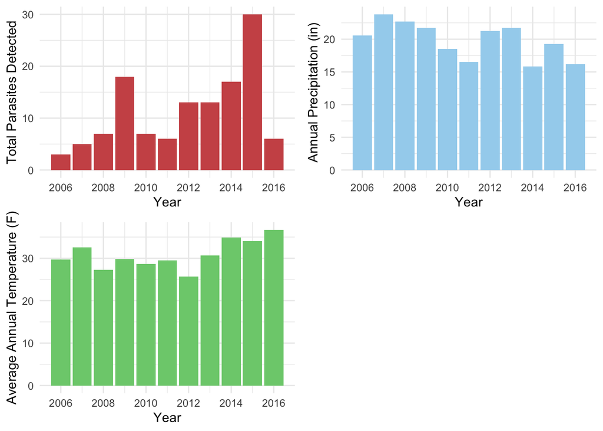

   ```r
   # plot annual parasites found
   parasite_bar <- ggplot(goose_2006_2016, aes(x=date,
                    y=total_parasite)) +
     geom_col(fill='indianred3') +
     labs(y='Total Parasites Detected',
          x='Year') +
     theme_minimal()

   # plot annual precipitation
   precip_bar <- ggplot(clim_data, aes(x=date, y=annual_precip_in)) +
     geom_col(fill='lightskyblue2') +
     theme_minimal() +
     theme(plot.title = element_text(hjust = 0.5)) +
     labs(x= 'Year',
          y = 'Annual Precipitation (in)')

   # plot annual average temperature
   temp_bar <- ggplot(clim_data, aes(x=date, y=avg_annual_temp)) +
     geom_col(fill='palegreen3') +
     theme_minimal() +
     labs(x='Year',
          y='Average Annual Temperature (F)')

   grid.arrange(parasite_bar, precip_bar, temp_bar, ncol = 2)
   ```

2. View how climate has changed over time, linearly. I kept a full data frame from 1923-2022 as well as one with the years specific to the parasite study. I am hoping that the larger sample size from the full climate data will demonstrate changes over time, even if the 10-year span of the study does not

   a. Summarise data over all years, and years of interest

   ```r
   # summary table of full climate data
   clim_data_full %>%
     summarise(mean_precip = mean(annual_precip_in, na.rm = TRUE),
               sd_precip = sd(annual_precip_in, na.rm = TRUE),
               mean_annual_temp = mean(avg_annual_temp, na.rm = TRUE),
               sd_annual_temp = sd(avg_annual_temp, na.rm = TRUE)) %>%
     gt() %>% tab_header('Climate Data Summary 1923-2022')
   ```

   Climate Data Summary 1923-2022

   | mean_precip | sd_precip | mean_annual_temp | sd_annual_temp |
   | --- | --- | --- | --- |
   | 17.65906 | 4.868277 | 29.96465 | 2.779712 |

   ```r
   # summary of study climate data
   clim_data %>%
     summarise(mean_precip = mean(annual_precip_in, na.rm = TRUE),
               sd_precip = sd(annual_precip_in, na.rm = TRUE),
               mean_annual_temp = mean(avg_annual_temp, na.rm = TRUE),
               sd_annual_temp = sd(avg_annual_temp, na.rm = TRUE)) %>%
     gt() %>% tab_header('Climate Data Summary 2006-2016')
   ```

   Climate Data Summary 2006-2016

   | mean_precip | sd_precip | mean_annual_temp | sd_annual_temp |
   | --- | --- | --- | --- |
   | 19.83091 | 2.769363 | 30.87273 | 3.357109 |

   b. Use full climate data to see how climate variables have changed over time

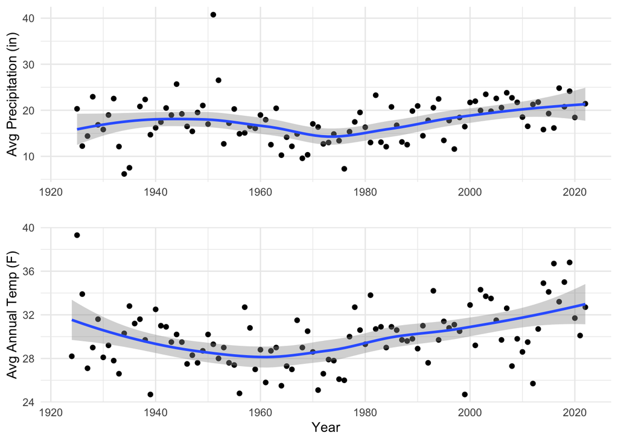

   ```r
   # plot precipitation over time
   precip_scatter <- ggplot(clim_data_full, aes(x=date, y=annual_precip_in)) +
     geom_point() +
     geom_smooth() +
     labs(x='', y='Avg Precipitation (in)') +
     theme_minimal()

   # plot average annual temp over time
   temp_scatter <- ggplot(clim_data_full, aes(x=date, y=avg_annual_temp)) +
     geom_point()+
     geom_smooth() +
       labs(x='Year', y='Avg Annual Temp (F)') +
     theme_minimal()

   grid.arrange(precip_scatter, temp_scatter, ncol=1)
   ```

3. Time series of infection over time - running into errors with `tsibble()` object type. For the homework, we used a `tsibble()` object before running the decomposition. I am able to coerce the `df` to a populated `tbl_df`, but when I run the decomposition it returns a blank item.

   ```r
   # # decomp rain
   # a <- tsibble::as_tsibble(clim_data_full, index='date')
   #
   # test_decomp <- a %>%
   #   model(STL(annual_precip_in))
   #
   # # plot rain decomp
   # components(test_decomp) %>%
   #   autoplot()
   ```

   ```r
   # # create summary table w/annual parasites found
   # parasite_sum <- goose_clim_full %>%
   #   group_by(year) %>%
   #   summarise(sum = sum(total_parasite)) %>%
   #   mutate(date = ymd(paste0(year, '01', '01'))) %>%
   #   as_tsibble()

   # # decompose trends, seasons, and remainder
   # parasite_decomp <- parasite_sum %>%
   #   model(STL(sum))
   #
   # # plot the components
   # parasite_decomp %>%  autoplot()
   ```